# Soluções: Atividade Prática 3

Econometria Aplicada à Finanças  
Mestrado Profissional em Administração

Autor

Prof. Dr. Washington S. da Silva

Data de Publicação

1 de setembro de 2026

## Questão 1 — Simulando dados de um modelo homocedástico

```r
# Fixa a semente para tornar a simulação reproduzível
set.seed(12345)

# Define o tamanho da amostra e os parâmetros populacionais
n <- 500
beta_0 <- 1
beta_1 <- 3
sigma <- 2

# Gera o regressor e o termo de erro homocedástico
x <- runif(n, min = -3, max = 3)
erro <- rnorm(n, mean = 0, sd = sigma)

# Calcula a variável dependente segundo o modelo populacional
y <- beta_0 + beta_1 * x + erro

# Organiza as variáveis simuladas
dados_homo <- tibble(x, erro, y)

# Estima o modelo por MQO
modelo_homo <- lm(y ~ x, data = dados_homo)

# Apresenta as estimativas dos coeficientes
broom::tidy(modelo_homo)
```

```
# A tibble: 2 × 5
  term        estimate std.error statistic   p.value
  <chr>          <dbl>     <dbl>     <dbl>     <dbl>
1 (Intercept)     1.08    0.0896      12.0 2.48e- 29
2 x               3.03    0.0514      58.9 2.12e-226
```

**a.** `beta_0`, `beta_1` e `sigma` são parâmetros populacionais fixados pelo pesquisador. Os vetores `x`, `erro` e `y` contêm realizações de variáveis aleatórias. O objeto `modelo_homo` armazena, entre outros resultados, os coeficientes estimados com a amostra simulada.

Portanto, `beta_1` contém o parâmetro populacional conhecido, igual a 3, enquanto o coeficiente de `x` retornado por `lm()` é $\hat\beta_1$, uma estatística cujo valor depende da amostra.

**b.** Nesta amostra, $\hat\beta_0\approx 1,076$ e $\hat\beta_1\approx 3,028$. As estimativas estão próximas de $\beta_0=1$ e $\beta_1=3$, mas não precisam ser exatamente iguais aos parâmetros porque dependem das realizações aleatórias de $x_i$ e $\varepsilon_i$ presentes nesta amostra.

**c.**

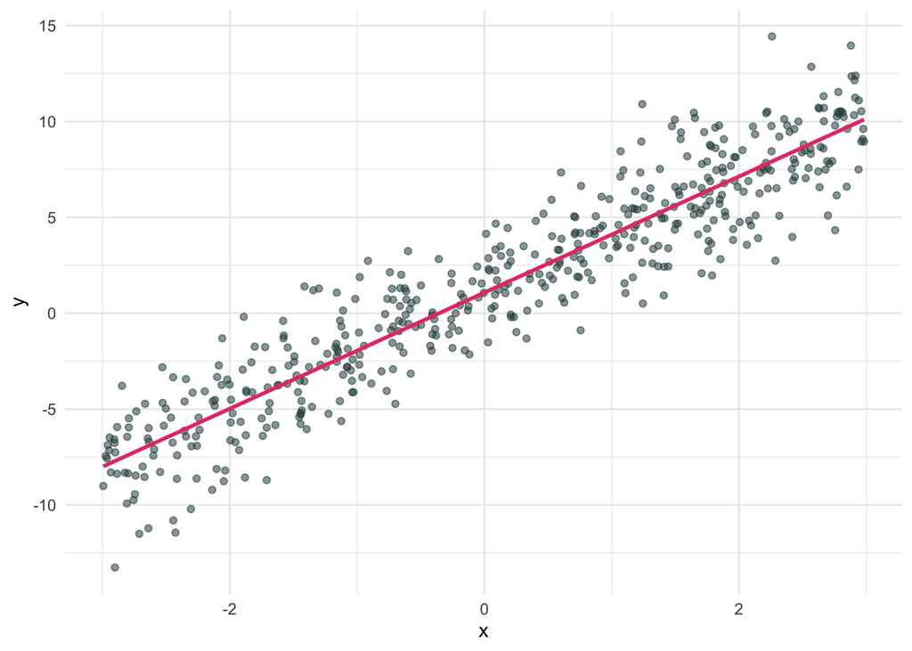

Amostra simulada e reta de regressão estimada no modelo homocedástico.

```r
# Representa os dados e acrescenta a reta estimada por MQO
ggplot(dados_homo, aes(x = x, y = y)) +
  geom_point(color = "darkslategrey", alpha = 0.55) +
  geom_smooth(method = "lm", formula = y ~ x, se = FALSE, color = "#E64173") +
  labs(x = "x", y = "y") +
  theme_minimal()
```

Cada ponto representa uma observação $(x_i,y_i)$, e a reta representa os valores ajustados $\hat y_i=\hat\beta_0+\hat\beta_1x_i$. A distância vertical entre um ponto e a reta estimada é o resíduo. A dispersão vertical parece aproximadamente constante ao longo de $x$, o que é coerente com o desvio-padrão condicional constante usado para simular os erros.

**d.** A simulação permite conhecer os parâmetros e os erros do processo gerador e, depois, comparar essas quantidades com as estimativas e os resíduos. Assim, podemos avaliar se um procedimento reconhece corretamente uma condição que foi definida pelo pesquisador. Uma única amostra, porém, é apenas uma realização aleatória e não revela toda a distribuição amostral do estimador. Para investigar uma propriedade geral, como ausência de viés, seria necessário repetir a simulação muitas vezes e analisar a distribuição das estimativas.

## Questão 2 — Simulando dados de um modelo heterocedástico

**a.**

```r
# Fixa a semente e define o modelo populacional
set.seed(12345)
n <- 500
beta_0 <- 1
beta_1 <- 3

# Gera o regressor
x <- runif(n, min = -3, max = 3)

# Define um desvio-padrão que aumenta com x
sigma_i <- 5 + 1.5 * x

# Interrompe a execução se algum desvio-padrão não for positivo
stopifnot(all(sigma_i > 0))

# Gera os erros e a variável dependente
erro <- rnorm(n, mean = 0, sd = sigma_i)
y <- beta_0 + beta_1 * x + erro

# Organiza as variáveis simuladas
dados_hetero <- tibble(x, sigma_i, erro, y)

# Verifica o intervalo dos desvios-padrão simulados
range(dados_hetero$sigma_i)
```

```
[1] 0.5102293 9.4729689
```

Os valores observados de `sigma_i` variam de aproximadamente 0,510 a 9,473. Esse intervalo está contido no intervalo teórico $[0{,}5;9{,}5]$, e todos os desvios-padrão são positivos.

**b.**

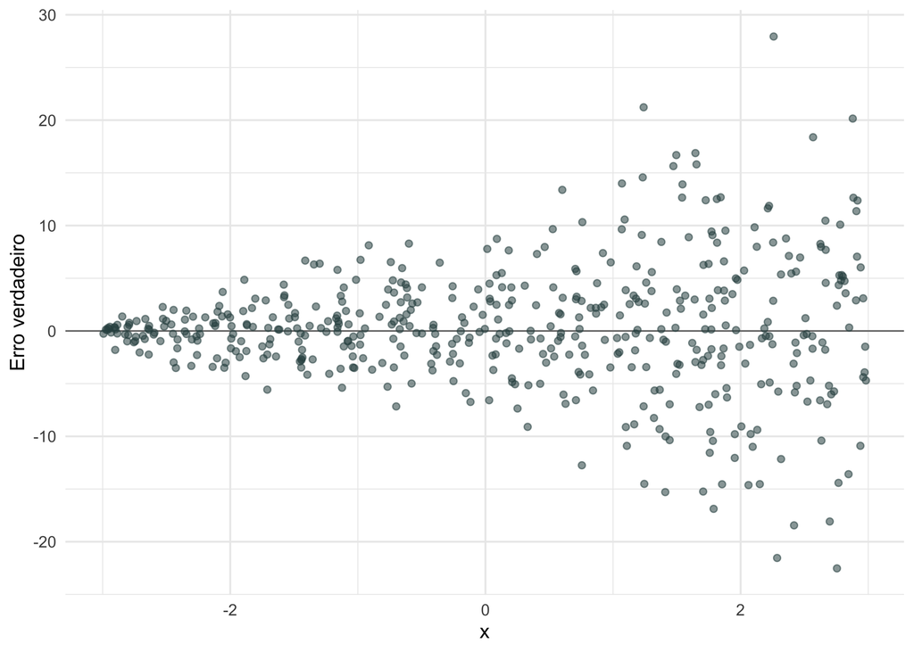

Erros verdadeiros no modelo heterocedástico simulado.

```r
# Representa os erros verdadeiros em função do regressor
ggplot(dados_hetero, aes(x = x, y = erro)) +
  geom_hline(yintercept = 0, linewidth = 0.4, color = "grey45") +
  geom_point(color = "darkslategrey", alpha = 0.55) +
  labs(x = "x", y = "Erro verdadeiro") +
  theme_minimal()
```

Os erros permanecem distribuídos em torno de zero ao longo de $x$, como determina $E(\varepsilon_i\mid x_i)=0$. Entretanto, sua dispersão aumenta com $x$, formando um funil. Esse padrão decorre de $\operatorname{Var}(\varepsilon_i\mid x_i)=(5+1{,}5x_i)^2$ e representa mudança da variância condicional, não da média condicional dos erros.

**c.**

```r
# Estima o modelo por MQO
modelo_hetero <- lm(y ~ x, data = dados_hetero)

# Apresenta as estimativas dos coeficientes
broom::tidy(modelo_hetero)
```

```
# A tibble: 2 × 5
  term        estimate std.error statistic  p.value
  <chr>          <dbl>     <dbl>     <dbl>    <dbl>
1 (Intercept)     1.26     0.266      4.75 2.70e- 6
2 x               3.05     0.153     20.0  1.45e-65
```

```r
# Acrescenta resíduos e valores ajustados à base simulada
dados_hetero <- dados_hetero |>
  mutate(
    residuo = residuals(modelo_hetero),
    ajustado = fitted(modelo_hetero)
  )

# Compara os erros e os resíduos das seis primeiras observações
dados_hetero |>
  select(erro, residuo) |>
  slice_head(n = 6)
```

```
# A tibble: 6 × 2
    erro residuo
   <dbl>   <dbl>
1  -5.65   -5.99
2   8.39    8.00
3   3.35    3.00
4 -12.2   -12.5
5  -1.22   -1.47
6   1.28    1.12
```

As estimativas são $\hat\beta_0\approx 1,265$ e $\hat\beta_1\approx 3,054$. Elas não coincidem exatamente com os parâmetros porque foram calculadas a partir de uma amostra aleatória.

O erro verdadeiro é $\varepsilon_i=y_i-\beta_0-\beta_1x_i$, enquanto o resíduo é $\hat\varepsilon_i=y_i-\hat\beta_0-\hat\beta_1x_i$. Como os coeficientes estimados não coincidem exatamente com os parâmetros, `erro` e `residuo` também não são idênticos.

**d.**

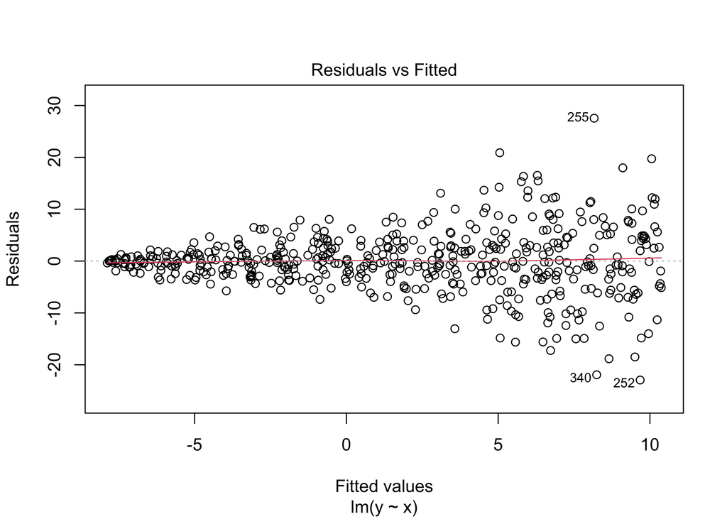

Resíduos contra valores ajustados no modelo heterocedástico.

```r
# Seleciona o gráfico Residuals vs Fitted
plot(modelo_hetero, which = 1)
```

Os resíduos permanecem distribuídos em torno de zero, sem deslocamento sistemático evidente de sua média. Sua dispersão vertical, porém, aumenta com os valores ajustados e forma um funil. Esse padrão não é compatível com variância condicional constante e sugere heterocedasticidade. Como se trata de um diagnóstico visual, a conclusão deve ser complementada por um teste formal.

**e.** Não. A heterocedasticidade, isoladamente, não torna os coeficientes de MQO viesados. Nesta simulação, $E(\varepsilon_i\mid x_i)=0$ continua válida; somente a variância condicional muda. Portanto, foi mantida a condição central para a ausência de viés dos estimadores de MQO.

## Questão 3 — Compreendendo o teste de White

**a.**

```r
# Fixa a semente e define o modelo populacional
set.seed(12345)
n <- 500
beta_0 <- 1
beta_1 <- 3

# Gera o regressor e define o desvio-padrão condicional
x <- runif(n, min = -3, max = 3)
sigma_i <- 2 + x^2

# Interrompe a execução se algum desvio-padrão não for positivo
stopifnot(all(sigma_i > 0))

# Gera os erros e calcula a variável dependente
erro <- rnorm(n, mean = 0, sd = sigma_i)
y <- beta_0 + beta_1 * x + erro

# Organiza a amostra e estima o modelo por MQO
dados_extremos <- tibble(x, sigma_i, erro, y)
modelo_extremos <- lm(y ~ x, data = dados_extremos)

# Acrescenta os resíduos à base
dados_extremos <- dados_extremos |>
  mutate(residuo = residuals(modelo_extremos))
```

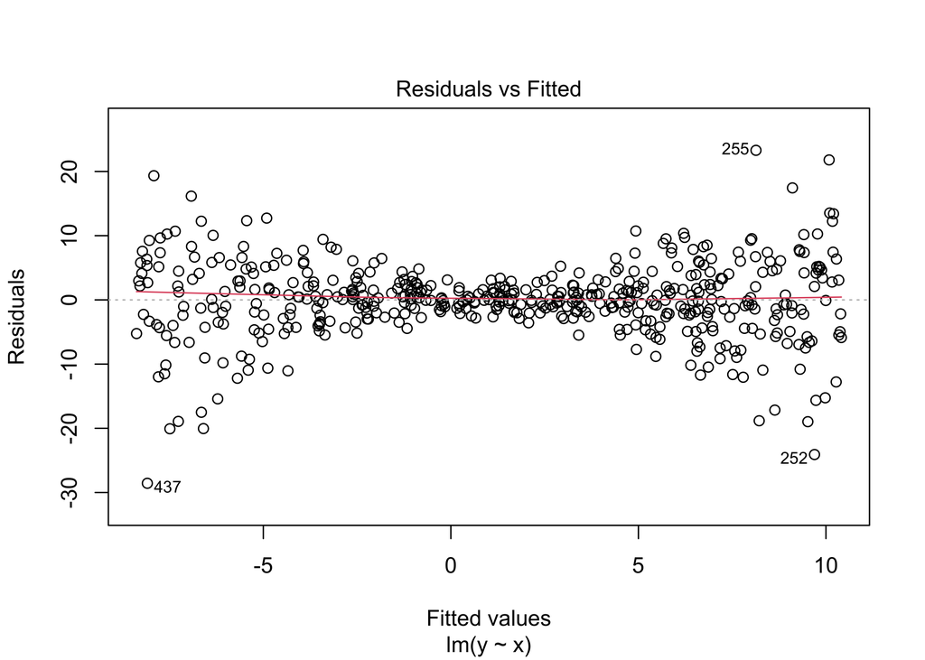

Resíduos contra valores ajustados no modelo com funil duplo.

```r
# Seleciona o gráfico Residuals vs Fitted
plot(modelo_extremos, which = 1)
```

A dispersão dos resíduos é menor na região central do gráfico e aumenta em suas duas extremidades. Isso é coerente com $\sigma_i=2+x_i^2$: o desvio-padrão é menor quando $x$ está próximo de zero e cresce à medida que $x$ se afasta de zero. O padrão de funil duplo sugere que a variância condicional não é constante.

**b.** O cálculo manual segue a regressão auxiliar do teste de White (White, 1980):

```r
# Estima a regressão auxiliar do teste de White
modelo_auxiliar <- lm(
  I(residuo^2) ~ x + I(x^2),
  data = dados_extremos
)

# Extrai o R-quadrado da regressão auxiliar
r2_auxiliar <- summary(modelo_auxiliar)$r.squared

# Calcula a estatística LM = n R-quadrado
estatistica_white <- nrow(dados_extremos) * r2_auxiliar

# Calcula o valor-p na cauda direita da distribuição qui-quadrado
valor_p_white <- pchisq(
  q = estatistica_white,
  df = 2,
  lower.tail = FALSE
)

# Exibe a estatística do teste e o valor-p
estatistica_white
```

```
[1] 83.61509
```

```r
valor_p_white
```

```
[1] 6.969689e-19
```

Testamos a hipótese de homocedasticidade, $H_0:\operatorname{Var}(\varepsilon_i\mid x_i)=\sigma^2$. Na regressão auxiliar, ela corresponde a $H_0:\alpha_1=\alpha_2=0$. A estatística LM é aproximadamente 83,615, e o valor-*p* é aproximadamente 6,97e-19. Como o valor-*p* é inferior a 5%, rejeitamos $H_0$ e concluímos que há evidência de heterocedasticidade.

Essa conclusão utiliza a distribuição qui-quadrado como aproximação assintótica. Os dois graus de liberdade correspondem às duas restrições sobre os coeficientes de `x` e `I(x^2)`; o intercepto não é contado.

**c.**

```r
# Executa o teste de White a partir do modelo estimado
resultado_white <- whitestrap::white_test(modelo_extremos)

# Exibe o resultado do teste
resultado_white
```

```
White's test results

Null hypothesis: Homoskedasticity of the residuals
Alternative hypothesis: Heteroskedasticity of the residuals
Test Statistic: 83.62
P-value: 0
```

A função retorna a mesma estatística do cálculo manual, salvo arredondamento: aproximadamente 83,615. Isso ocorre porque, nesta regressão simples com inclinação estimada diferente de zero, os valores ajustados usados pelo pacote são uma transformação linear de `x`. Assim, a regressão com os valores ajustados e seus quadrados contém a mesma informação que a regressão com `x` e `I(x^2)`.

A concordância ajuda a confirmar que o cálculo manual foi implementado corretamente, mas não substitui a interpretação da hipótese de homocedasticidade e da decisão estatística.

O pacote retorna o valor-*p* como `0` porque calcula internamente `1 - pchisq()`. Para uma estatística muito elevada, `pchisq()` é representada numericamente como `1`, e a subtração perde a precisão necessária para recuperar a pequena probabilidade da cauda direita. O cálculo manual com `lower.tail = FALSE` calcula essa cauda diretamente e retorna aproximadamente 6,97e-19. Portanto, o valor-*p* teórico não é literalmente zero, embora a decisão ao nível de 5% continue sendo rejeitar a hipótese nula de homocedasticidade.

**d.** Mantida a exogeneidade:

1. **Viés:** a heterocedasticidade, por si só, não torna os coeficientes de MQO viesados. A média condicional zero dos erros continua sendo a condição relevante para esse resultado.
2. **Eficiência:** o teorema de Gauss–Markov deixa de garantir que MQO seja o estimador linear não viesado de menor variância.
3. **Inferência convencional:** a fórmula homocedástica da matriz de variância-covariância deixa de ser válida. Os erros-padrão convencionais podem ser subestimados ou superestimados, comprometendo os testes de hipótese, os valores-*p* e os intervalos de confiança calculados a partir deles.

Essas consequências explicam por que a heterocedasticidade é relevante mesmo quando não introduz viés nos coeficientes estimados.

## Referências

WHITE, H. A heteroskedasticity-consistent covariance matrix estimator and a direct test for heteroskedasticity. **Econometrica**, v. 48, n. 4, p. 817–838, 1980.